# Homework09

## Stats 21 - Homework 09 {-}

### Blair Lee - 005721089

### Due June 10, 2023 by 11:59pm {-}

Problems have been adapted from the exercises in Think Python 2nd Ed by Allen B. Downey. https://greenteapress.com/thinkpython2/html/thinkpython2017.html

The questions have been entered into this document. You will modify the document by entering your code.

Make sure you run the cell so the requested output is visible.

```python
from IPython.display import display, Math, Latex
```

### Problem 1. Convert integers to Roman number {-}

Please write define a class (we got you started wtih some useful attributes) that will convert integers to Roman numbers. So for example the number 2023 should convert to 'MMXXIII'

If a float is received, it should convert the float to integer without error.

You should be able to program this one without importing any libraries/modules.

```python
class IntegerToRoman:
    def __init__(self):
        self.values = [1000, 900, 500, 400, 100, 90, 50, 40, 10, 9, 5, 4, 1]
        self.symbols = ["M", "CM", "D", "CD", "C", "XC", "L", "XL", "X", "IX", "V", "IV", "I"]

    def int_to_roman(self, number):
        if type(number) not in [int, float]:
            print("WARNING: the inputted value is not a number! Returning empty string.")
            return ""
        number = round(number)
        i = 0
        roman = ""
        while number:
            division = number // self.values[i]
            number %= self.values[i]
            while division:
                roman += self.symbols[i]
                division -= 1
            i += 1
        return roman
```

```python
converter = IntegerToRoman()
```

```python
# Uncomment the next line and run
converter.int_to_roman(2023)
```

```
'MMXXIII'
```

```python
# Uncomment the next lines and run
x = [4, 9, 19.7, 53, 102, 507, 2022, True, False]
for i in x:
    print(IntegerToRoman().int_to_roman(i))
```

```
IV
IX
XX
LIII
CII
DVII
MMXXII
WARNING: the inputted value is not a number! Returning empty string.

WARNING: the inputted value is not a number! Returning empty string.
```

### Problem 2. String Cleaning {-}

One of the reasons we use Object Oriented Programming is to reuse code in the current and possibly different applications.

Strings, with only a few exceptions, are unclean.

Please construct a class named StringCleaner that will accept a test string and perform the following actions found below.

You may import any libraries/modules that you have seen presented in this class and any of the modules from the Python Standard library that you may not have seen.

```python
import string

class StringCleaner:
    def __init__(self, string):
        self.string = string

    def clean_string_tolower(self):
        return self.string.lower()

    def clean_string_toupper(self):
        return self.string.upper()

    def remove_punctuation(self):
        no_punc = ""
        punc = '''!()-[]{};:'"\,<>./?@#$%^&*_~'''
        for i in self.string:
            if i not in punc:
                no_punc += i
        return no_punc

    def remove_capitalization(self):
        return self.string.lower()
```

```python
test_string = "I'm findin' ways to articulate the feelin' I'm goin' through I just can't say I don't love you (Yeah) 'Cause I love you, yeah It's hard for me to communicate the thoughts that I hold But tonight, I'm gon' let you know Let me tell the truth Baby, let me tell the truth, yeah"
```

```python
# uncomment the next line and run
test = StringCleaner(test_string)
```

```python
# uncomment the next line and run
test.clean_string_tolower()
```

```
"i'm findin' ways to articulate the feelin' i'm goin' through i just can't say i don't love you (yeah) 'cause i love you, yeah it's hard for me to communicate the thoughts that i hold but tonight, i'm gon' let you know let me tell the truth baby, let me tell the truth, yeah"
```

```python
# uncomment the next line and run
test.clean_string_toupper()
```

```
"I'M FINDIN' WAYS TO ARTICULATE THE FEELIN' I'M GOIN' THROUGH I JUST CAN'T SAY I DON'T LOVE YOU (YEAH) 'CAUSE I LOVE YOU, YEAH IT'S HARD FOR ME TO COMMUNICATE THE THOUGHTS THAT I HOLD BUT TONIGHT, I'M GON' LET YOU KNOW LET ME TELL THE TRUTH BABY, LET ME TELL THE TRUTH, YEAH"
```

```python
# uncomment the next line and run
test.remove_punctuation()
```

```
'Im findin ways to articulate the feelin Im goin through I just cant say I dont love you Yeah Cause I love you yeah Its hard for me to communicate the thoughts that I hold But tonight Im gon let you know Let me tell the truth Baby let me tell the truth yeah'
```

```python
# uncomment the next line and run
test.remove_capitalization()
```

```
"i'm findin' ways to articulate the feelin' i'm goin' through i just can't say i don't love you (yeah) 'cause i love you, yeah it's hard for me to communicate the thoughts that i hold but tonight, i'm gon' let you know let me tell the truth baby, let me tell the truth, yeah"
```

```python
# uncomment the next line and run
test_string.lower()
```

```
"i'm findin' ways to articulate the feelin' i'm goin' through i just can't say i don't love you (yeah) 'cause i love you, yeah it's hard for me to communicate the thoughts that i hold but tonight, i'm gon' let you know let me tell the truth baby, let me tell the truth, yeah"
```

### Problem 3. Rolling Dice {-}

Please construct a class (called DiceRoll below, but name yours whatever) with a method named roll that allows the user to specify the number of die rolled, and the number of sides.

```python
import random
import seaborn as sns

random.seed(1)

class DiceRoll:
    def __init__(self, sides, num_dice):
        self.sides = sides
        self.num_dice = num_dice

    def random_roll(self):
        results = []
        rolls = self.num_dice
        while rolls:
            results.append(random.randint(1, self.sides))
            rolls -= 1
        return results
```

```python
# Roll two 6-sided dice
two_six = DiceRoll(6, 2)
two_six.random_roll()
```

```
[2, 5]
```

```python
# Roll three 10-sided dice
three_ten = DiceRoll(10, 3)
three_ten.random_roll()
```

```
[2, 5, 2]
```

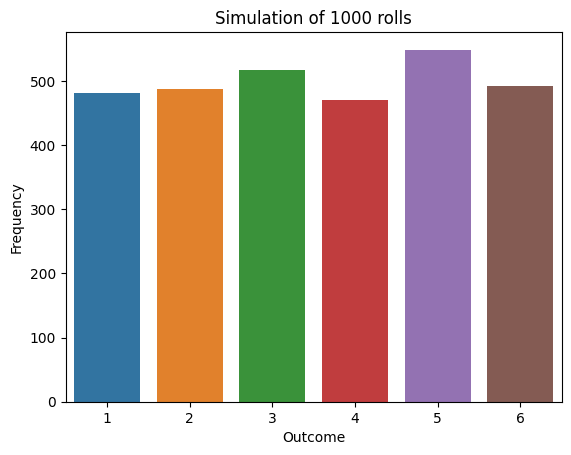

```python
# Roll three 6 sided dice 1000 times and plot the results
all_rolls = []
many = 1000
while many:
    three_six = DiceRoll(6, 3)
    temp = three_six.random_roll()
    for i in temp:
        all_rolls.append(i)
    many -= 1
sns.countplot(x = all_rolls)
plt.xlabel("Outcome")
plt.ylabel("Frequency")
plt.title("Simulation of 1000 rolls")
plt.show()
```